# Analysis of real-time qPCR data

Mahmoud Ahmed

2020-02-25

# Overview

Quantitative real-time PCR is an important technique in medical and bio-medical applications. The `pcr` package provides a unified interface for quality assessing, analyzing and testing qPCR data for statistical significance. The aim of this document is to describe the different methods and modes used to relatively quantify gene expression of qPCR and their implementation in the `pcr` package.

# Getting started

The `pcr` is available on CRAN. To install it, use:

```r
# install package CRAN
install.packages('pcr')
```

The development version of the package can be obtained through:

```r
# install package from github
devtools::install_github('MahShaaban/pcr')
```

```r
# load required libraries
library(pcr)
```

The following chunk of code locates a dataset of $C_T$ values of two genes from 12 different samples and performs a quick analysis to obtain the expression of a target gene **c-myc** normalized by a control GAPDH in the **Kidney** samples relative to the brain samples. `pcr_analyze` provides different methods, the default one that is used here is ‘delta_delta_ct’ applies the popular ($\Delta\Delta C_T$) method.

```r
# default mode delta_delta_ct
## locate and read raw ct data
fl <- system.file('extdata', 'ct1.csv', package = 'pcr')
ct1 <- read.csv(fl)

## add grouping variable
group_var <- rep(c('brain', 'kidney'), each = 6)

# calculate all values and errors in one step
## mode == 'separate_tube' default
res <- pcr_analyze(ct1,
                   group_var = group_var,
                   reference_gene = 'GAPDH',
                   reference_group = 'brain')

res
```

| group | gene | normalized | calibrated | relative_expression | error | lower | upper |
| --- | --- | --- | --- | --- | --- | --- | --- |
| brain | c_myc | 6.860 | 0.000 | 1.000000 | 0.17395402 | 0.886410 | 1.128146 |
| kidney | c_myc | 4.365 | -2.495 | 5.637283 | 0.09544632 | 5.276399 | 6.022850 |

The output of `pcr_analyze` is explained in the documentation of the function `?pcr_analyze` and the method it calls `?pcr_ddct` as well as in a later scion of this document. Briefly, the input includes the $C_T$ value of c-myc `normalized` to the control GAPDH, The `calibrated` value of c-myc in the kidney relative to the brain samples and the final `relative_expression` of c-myc. In addition, an `error` term and a `lower` and `upper` intervals are provided.

The previous analysis makes a few assumptions that will be explained later in this document. One of which is a perfect amplification efficiency of the PCR reaction. To assess the validity of this assumption, `pcr_assess` provides a method called `efficiency`. The input `data.frame` is the $C_T$ values of c-myc and GAPDH at different input amounts/dilutions.

```r
## locate and read data
fl <- system.file('extdata', 'ct3.csv', package = 'pcr')
ct3 <- read.csv(fl)

## make a vector of RNA amounts
amount <- rep(c(1, .5, .2, .1, .05, .02, .01), each = 3)

## calculate amplification efficiency
res <- pcr_assess(ct3,
                  amount = amount,
                  reference_gene = 'GAPDH',
                  method = 'efficiency')
res
```

| gene | intercept | slope | r_squared |
| --- | --- | --- | --- |
| c_myc | 3.01448 | 0.02645619 | 0.02070273 |

# Background

## Glossary

- **Amplification efficiency**: The ability of the reaction to amplify a certain amount of input RNA in a sample
- $C_T$: *Cycle Threshold* is the number of cycles required for the fluorescent signal to cross the threshold
- $\Delta C_T$: Difference between two $C_T$ values (e.g. $C_{T, c-myc} - C_{T, GAPDH}$)
- $\Delta \Delta C_T$: Difference between two $\Delta C_T$ values (e.g. $\Delta C_{T, Treatment} - \Delta C_{T, Treatment}$)
- **Reference gene**: A gene known not to change its expression between the groups of interest, so any change in its signal should be due to the amplification of the PCR. Used for *normalization*. (e.g. GAPDH or $\beta$-actin)
- **Reference group**: An experimental group used to express mRNA level in comparison to. Used for *caliberation*. (e.g. control or time point 0)
- **Standard**: A sample of known concentration

## Analysis methods

In contrast with the absolute quantification of the amount of mRNA in a sample, relative quantification uses a internal control (reference gene) and/or a control group (reference group) to quantify the mRNA of interest relative to these references. This relative quantification is sufficient to draw conclusions in most of the bio-medical applications involving qPCR. A few methods were developed to perform these relative quantification. These methods require different assumptions and models. The most common two of these methods are explained here.

### Comparative $C_T$ methods

The comparative $C_T$ methods assume that the cDNA templates of the gene/s of interest as well as the control/reference gene have similar amplification efficiency. And that this amplification efficiency is near perfect. Meaning, at a certain threshold during the linear portion of the PCR reaction, the amount of the gene of the interest and the control double each cycle. Another assumptions is that, the expression difference between two genes or two samples can be captured by subtracting one (gene or sample of interest) from another (reference). This final assumption requires also that these references doesn’t change with the treatment or the course in question.  
The formal derivation of the double delta $C_T$ model is described here (Livak and Schmittgen 2001). Briefly,  
The $\Delta\Delta C_T$ is given by:

$$\Delta\Delta C_T = \Delta C_{T,q} - \Delta C_{T,cb}$$

And the relative expression by:

$$2^{-\Delta\Delta C_T}$$

Where:

- $\Delta C_{T,q}$ is the difference in the $C_T$ (or their ) of a *gene* of interest and a *reference* gene in a group of interest
- $\Delta C_{T,cb}$ is the the difference in the $C_T$ (or their ) of a *gene* of interest and a *reference* gene in a *reference* group

And the error term is given by:

$$s = \sqrt{s_1^2 + s_2^2}$$

Where:

- $s_1$ is the of a *gene* of interest
- $s_2$ is the of a *reference* gene

### Standard curve methods

In comparison, this model doesn’t assume perfect amplification but rather actively use the amplification in calculating the relative expression. So when the amplification efficiency of all genes are 100% both methods should give similar results. The standard curve method is applied using two steps. First, serial dilutions of the mRNA from the samples of interest are used as input to the PCR reaction. The linear trend of the log input amount and the resulting $C_T$ values for each gene are used to calculate an intercept and a slope. Secondly, these intercepts and slopes are used to calculate the amounts of mRNA of the genes of interest and the control/reference in the samples of interest and the control sample/reference. These amounts are finally used to calculate the relative expression in a manner similar to the later method, just using division instead of subtraction.  
The formal derivation of the model is described here (Yuan et al. 2006). Briefly,  
The amount of RNA in a sample is given by:

$$\log amount = \dfrac{C_T - b}{m}$$

And the relative expression is given by:

$$10^{\log amount}$$

where:

- $C_T$ is the cycle threshold of a gene
- $b$ is the of $C_T$ ~ log10 input amount
- $m$ is the of $C_T$ ~ log10 input amount

And the error term is given by:

$$s = (cv)(\bar X)$$

Where:

$$cv = \sqrt{cv_1^2 + cv_2^2}$$

Where:

- $s$ is the
- $\bar X$ is the
- $cv$ is the or relative standard deviation

## Quality Assessment of qPCR

Fortunately, regardless of the method used in the analysis of qPCR data, The quality assessment are done in a similar way. It requires an experiment similar to that of calculating the standard curve. Serial dilutions of the genes of interest and controls are used as input to the reaction and different calculations are made.

- The amplification efficiency is approximated be the linear trend between the difference between the $C_T$ value of a gene of interest and a control/reference ($\Delta C_T$) and the log input amount. This piece of information is required when using the $\Delta\Delta C_T$ model. Typically, the slope of the curve should be very small and the $R^2$ value should be very close to one. A value of the amplification efficiency itself is given by $10 ^ {-1/slope}$ and should be close to 2. Other analysis methods are recommended when this is not the case.
- Similar curves are required for each gene using the $C_T$ value instead of the difference for applying the standard curve method. In this case, a separate slope and intercept are required for the calculation of the relative expression.

## Testing statistical significance

Using the later two methods and there assumptions, useful statistics such as p-values and confidence intervals can be calculated.

### Two-group tests

Assuming that the assumptions of the first methods are holding true, the simple t-test can be used to test the significance of the difference between two conditions ($\Delta C_T$). t-test assumes in addition, that the input $C_T$ values are normally distributed and the variance between conditions are comparable. Wilcoxon test can be used when sample size is small and those two last assumptions are hard to achieve.

### Linear regression

Two use the linear regression here. A null hypothesis is formulated as following,

$$C_{T, target, treatment} - C_{T, control, treatment} = C_{T, target, control} - C_{T, control, control} \quad \textrm{or} \quad \Delta\Delta C_T$$

This is exactly the ($\Delta\Delta C_T$) as explained earlier. So the $\Delta\Delta C_T$ is estimated and the null is rejected when $\Delta\Delta C_T \ne 0$.

# The `pcr` package

## Motivation

Table 1: Relative quantification using comparative ($\Delta\Delta C_T$) method (separate tubes)

[output not shown]

Table 2:Relative quantification using the standard curve method (separate tube)

| Tissue | c-myc (ng) | GAPDH (ng) | c-myc$_N$ (norm. to GAPDH) | c-myc$_N$ (Rel. to Brain) |
| --- | --- | --- | --- | --- |
| Brain | 0.033 | 0.51 |  |  |
|  | 0.043 | 0.56 |  |  |
|  | 0.036 | 0.59 |  |  |
|  | 0.043 | 0.53 |  |  |
|  | 0.039 | 0.51 |  |  |
|  | 0.040 | 0.52 |  |  |
| **Average** | 0.039 $\pm$ 0.004 | 0.54 $\pm$ 0.034 | 0.07 $\pm$ 0.008 | 1.0 $\pm$ 0.12 |
| Kidney | 0.40 | 0.96 |  |  |
|  | 0.41 | 1.06 |  |  |
|  | 0.41 | 1.05 |  |  |
|  | 0.39 | 1.07 |  |  |
|  | 0.42 | 1.06 |  |  |
|  | 0.43 | 0.96 |  |  |
| **Average** | 0.41 $\pm$ 0.016 | 1.02 $\pm$ 0.052 | 0.40 $\pm$ 0.025 | 5.5 $\pm$ 0.35 |

Table 3: Relative quantification using comparative ($\Delta\Delta C_T$) method (same tube)

| Tissue | c-myc $C_T$ | GAPDH $C_T$ | $\Delta C_T$ (c-myc - GAPDH) | $\Delta\Delta C_T$ ($Ave.\Delta C_T - Ave. \Delta C_{T,Brain}$) | c-myc$_N$ (Rel. to Brain) |
| --- | --- | --- | --- | --- | --- |
| Brain | 32.38 | 25.07 | 7.31 |  |  |
|  | 32.08 | 25.29 | 6.79 |  |  |
|  | 32.35 | 25.32 | 7.03 |  |  |
|  | 32.08 | 25.24 | 6.84 |  |  |
|  | 32.34 | 25.17 | 7.17 |  |  |
|  | 32.13 | 25.29 | 6.84 |  |  |
| **Average** |  |  | 6.99 $\pm$ 0.21 | 0.00 $\pm$ 0.21 | 1.0 (0.86–1.15) |
| Kidney | 28.73 | 24.30 | 4.43 |  |  |
|  | 28.84 | 24.32 | 4.52 |  |  |
|  | 28.51 | 24.31 | 4.20 |  |  |
|  | 28.86 | 24.25 | 4.61 |  |  |
|  | 28.86 | 24.34 | 4.52 |  |  |
|  | 28.70 | 24.18 | 4.52 |  |  |
| **Average** |  |  | 4.47 $\pm$ 0.14 | –2.53 $\pm$ 0.14 | 5.77 (5.23–6.37) |

Table 4: Relative quantification using the standard curve method (same tube)

[output not shown]

Table 5: Average $C_T$ value for c-myc and GAPDH at different input amounts

[output not shown]

Table 6: Statistical significance using different testing methods

| Test | $\Delta\Delta C_T$ (estimate) | p-value | Confidence Interval |
| --- | --- | --- | --- |
| Multiple Regression | -0.6848 | 0.0001 | (-0.4435, -0.9262) |
| ANOVA | -0.6848 | 0.0001 | (-0.4435, -0.9262) |
| t-test | -0.6848 | 0.0001 | (-0.4147, -0.955) |
| Wilcoxon test | -0.6354 | 0.0001 | (-0.4227, -0.8805) |

## Assess `pcr_assess`

`pcr_assess` is a wrapper for the implemented quality assessment methods; `pcr_efficiency` and `pcr_standard`. Both methods can be called directly using the method names or through `pcr_assess` by passing a string to the argument `method`; ‘efficiency’ or ‘standard_curve’ for calculating the amplification efficiency or the standard curve for each gene respectively.

### Amplification efficiency `pcr_efficiency`

To calculate the amplification efficiency in a qPCR experiment, the main input is a `data.frame` with columns contain the $C_T$ values for each gene and rows correspond to the different input amounts/dilutions (Table 5).

The following code apply the calculation on the `data.frame`, `ct3`. It has two columns c_myc and GAPDH and 3 rows for each of the input amounts coded in the variable `amounts`. A reference gene passed to the `reference_gene` argument, in this case, the column name GAPDH.

```r
library(pcr)
library(ggplot2)
library(cowplot)
```

```r
## locate and read data
fl <- system.file('extdata', 'ct3.csv', package = 'pcr')
ct3 <- read.csv(fl)

## make a vector of RNA amounts
amount <- rep(c(1, .5, .2, .1, .05, .02, .01), each = 3)

## calculate amplification efficiency
res <- pcr_assess(ct3,
                  amount = amount,
                  reference_gene = 'GAPDH',
                  method = 'efficiency')
knitr::kable(res, caption = 'Table 7: amplification efficiency of c-myc')
```

Table 7: amplification efficiency of c-myc

| gene | intercept | slope | r_squared |
| --- | --- | --- | --- |
| c_myc | 3.01448 | 0.0264562 | 0.0207027 |

The output of `pcr_assess` is a `data.frame` of 4 columns and *n* rows equals the input genes except for the reference. For each gene an *intercept*, *slope* and $R^2$ is calculated for a the difference between it and the reference ($\Delta C_T$) (Table 7).

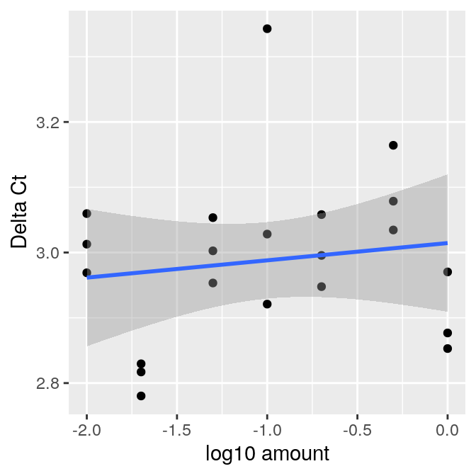

Figure 1: Amplification efficiency of c-myc

```r
gg <- pcr_assess(ct3,
           amount = amount,
           reference_gene = 'GAPDH',
           method = 'efficiency',
           plot = TRUE)
gg +
  labs(x = 'log10 amount', y = 'Delta Ct') +
  theme(strip.background = element_blank(),
        strip.text = element_blank())
```

The relevant summaries in calculating *efficiency* is the `slope`. Typically, `slope` should be very low (less than 0.1). Means the $\Delta C_T$ are not changing much as a consequence of changing the input concentration. A value of the amplification efficiency itself is given by $10 ^ {-1/slope}$ and should be close to 2.

### Standard curve `pcr_standard`

To calculate the standard curve for individual genes, `pcr_assess` takes a `data.frame` similar to that described above as input `ct3`, and the same `amount` variable. The following code calculates the curves for the two columns/genes by fitting a line between their $C_T$ values and the log input amounts.

```r
## calculate standard curve
res <- pcr_assess(ct3,
                  amount = amount,
                  method = 'standard_curve')
knitr::kable(res, caption = 'Table 8: Standard curves of c-myc and GAPDH')
```

Table 8: Standard curves of c-myc and GAPDH

| gene | intercept | slope | r_squared |
| --- | --- | --- | --- |
| c_myc | 25.69669 | -3.388095 | 0.9965504 |
| GAPDH | 22.68221 | -3.414551 | 0.9990278 |

The output put is similar to the previous call, except when ‘standard_curve’ is passed to `method` curves are calculated for individual genes, column `gene` (Table 8).

The information of the standard curves are required when using the standard curve methods, so we retain the relevant ones in the variables `intercept` and `slope`. Typically, the `r_squared` should be close to 1.

```r
intercept <- res$intercept
slope <- res$slope
```

When the argument `plot` is `TRUE` a graph is returned instead. A panel for each gene showing the raw $C_T$ values and the log input amounts (Fig. 2).

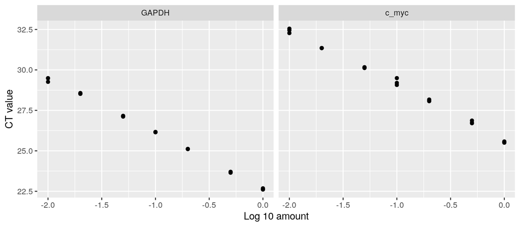

Figure 2: Standard curve of c-myc and GAPDH

```r
gg <- pcr_assess(ct3,
           amount = amount,
           method = 'standard_curve',
           plot = TRUE)
gg +
  labs(x = 'Log 10 amount', y = 'CT value')
```

## Analyze `pcr_analyze`

Similarly, `pcr_analyze` is a wrapper and unified interface for difference analysis models; `pcr_ddct`, `pcr_dct` and `pcr_curve`. The models can be invoked by calling these functions directly or through the argument `method` to `pcr_analyze`. Possible input to the argument `method` are ‘delta_delta_ct’, ‘delta_ct’ and ‘relative_curve’ for calculating the double delta $C_T$, delta $C_T$ and the standard curve models respectively.

### Doube delta $C_T$ ($\Delta\Delta C_T$) `pcr_ddct`

To apply the double delta $C_T$ model, the default `method` of `pcr_analyze`, the main input is a `data.frame` with columns containing the genes and the rows the $C_T$ values from different samples. In addition, a group variable `group_var` corresponding to these rows/samples is required. Finally, a `reference_gene` and a `reference_group` are entered.

The following code chunk applies this method to a `data.frame` of 12 samples from 2 groups `ct1` (Table 1).

```r
# default mode delta_delta_ct
## locate and read raw ct data
fl <- system.file('extdata', 'ct1.csv', package = 'pcr')
ct1 <- read.csv(fl)

## add grouping variable
group_var <- rep(c('brain', 'kidney'), each = 6)

# calculate all values and errors in one step
## mode == 'separate_tube' default
res1 <- pcr_analyze(ct1,
  group_var = group_var,
  reference_gene = 'GAPDH',
  reference_group = 'brain')

knitr::kable(res1, caption = 'Table 9: Double delta $C_T$ method (separate tubes)')
```

Table 9: Double delta $C_T$ method (separate tubes)

| group | gene | normalized | calibrated | relative_expression | error | lower | upper |
| --- | --- | --- | --- | --- | --- | --- | --- |
| brain | c_myc | 6.860 | 0.000 | 1.000000 | 0.1739540 | 0.886410 | 1.128146 |
| kidney | c_myc | 4.365 | -2.495 | 5.637283 | 0.0954463 | 5.276399 | 6.022850 |

The output of `pcr_analyze` is 8 columns; contains the calculations of each gene in each group and the error terms (Table 9). This analysis uses the default `mode`, ‘separate_tube’ as the input dataset came for an experiment where the target c_myc and the control gene GAPDH were ran in separate tubes.

In contrast, the `ct2` dataset, also shown in Table 3, came from an identical experiment except the samples were run in the same tube. So the following analysis invokes a different `mode`, ‘same_tube’.

```r
# calculate all values and errors in one step
## mode == 'same_tube'
res2 <- pcr_analyze(ct2,
  group_var = group_var,
  reference_gene = 'GAPDH',
  reference_group = 'brain',
  mode = 'same_tube')

knitr::kable(res2, caption = 'Table 10: Double delta $C_T$ method (same tube)')
```

Table 10: Double delta $C_T$ method (same tube)

| group | gene | normalized | calibrated | relative_expression | error | lower | upper |
| --- | --- | --- | --- | --- | --- | --- | --- |
| brain | c_myc | 6.996667 | 0.00 | 1.000000 | 0.2103014 | 0.8643567 | 1.156930 |
| kidney | c_myc | 4.466667 | -2.53 | 5.775717 | 0.1425015 | 5.2324932 | 6.375336 |

The only difference here is that the average of the $C_T$ values for the target gene c_myc is calculated after normalizing by the reference gene GAPDH. The rest of the calculations are expected to be slightly different than the previous case (Table 10).

Figure 3 shows the results of these two analysis. Bars represent the average relative expression of c-myc in the kidney, normalized by GAPDH and calibrated by the brain. The error bars are the standard deviations.

```r
gg1 <- pcr_analyze(ct1,
  group_var = group_var,
  reference_gene = 'GAPDH',
  reference_group = 'brain',
  plot = TRUE) +
  labs(x = '', y = 'Relative mRNA expression') +
  ggtitle(label = 'Separate tubes')
```

```r
gg2 <- pcr_analyze(ct2,
  group_var = group_var,
  reference_gene = 'GAPDH',
  reference_group = 'brain',
  mode = 'same_tube',
  plot = TRUE) +
  labs(x = '', y = 'Relative mRNA expression') +
  ggtitle(label = 'Same tubes')
```

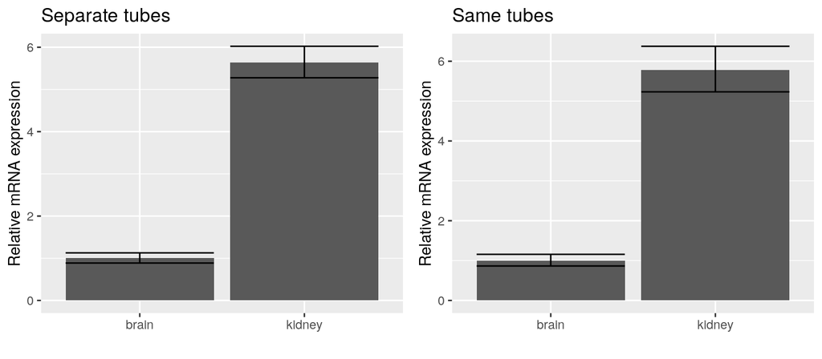

Figure 3: Relative expression of c-myc using double delta $C_T$

```r
plot_grid(gg1, gg2)
```

### Delta $C_T$ ($\Delta C_T$) `pcr_dct`

This method is a variation of the double delta $C_T$ model. It can be used to calculate the fold change of in one sample relative to the others. For example, it can be used to compare and choosing a control/reference genes.

```r
## example to check fold change of control gens
## locate and read file
fl <- system.file('extdata', 'ct1.csv', package = 'pcr')
ct1 <- read.csv(fl)

## make a data.frame of two identical columns
pcr_hk <- data.frame(
  GAPDH1 = ct1$GAPDH,
  GAPDH2 = ct1$GAPDH
  )

## add grouping variable
group_var <- rep(c('brain', 'kidney'), each = 6)
```

Here, we used the column GAPDH from the dataset `ct1` to make a `data.frame`, `pcr_hk` of two identical columns GAPDH1 and GAPDH2 two show how such comparison can be done.

The input to `pcr_analyze` is identical to that of the previous call, only `method` is specified this time to ‘delta_ct’.

```r
# delta_ct method
## calculate caliberation
res <- pcr_analyze(pcr_hk,
            group_var = group_var,
            reference_group = 'brain',
            method = 'delta_ct')

knitr::kable(res, caption = 'Table 11: Delta $C_T$ method')
```

Table 11: Delta $C_T$ method

| group | gene | calibrated | fold_change | error | lower | upper |
| --- | --- | --- | --- | --- | --- | --- |
| brain | GAPDH1 | 0.000 | 1.000000 | 0.0913783 | 0.9386256 | 1.065388 |
| kidney | GAPDH1 | -0.965 | 1.952063 | 0.0777174 | 1.8496888 | 2.060104 |
| brain | GAPDH2 | 0.000 | 1.000000 | 0.0913783 | 0.9386256 | 1.065388 |
| kidney | GAPDH2 | -0.965 | 1.952063 | 0.0777174 | 1.8496888 | 2.060104 |

Similarly, the output contains the calculated model and the error terms (Table 11). The difference here will be skipping the normalization step and calibrating the $C_T$ values of all genes to a `reference_group`.

Figure 4 shows the average relative fold change of the identical housekeeping genes and there error terms in two tissue samples.

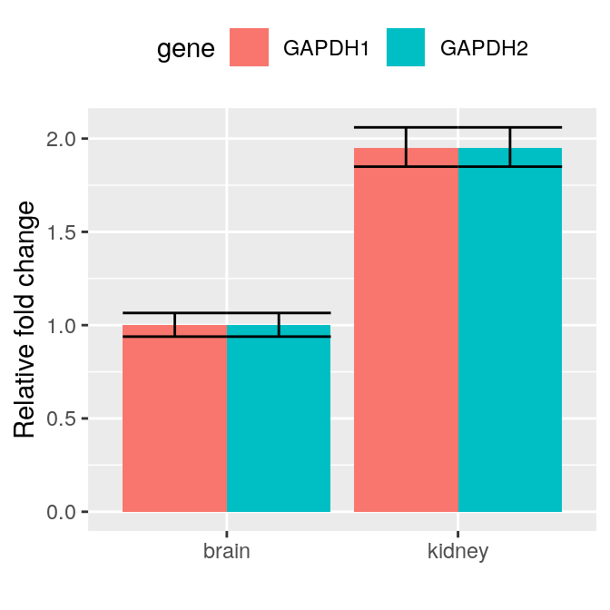

Figure 4: GAPDH relative fold change using delta $C_T$

```r
pcr_analyze(pcr_hk,
            group_var = group_var,
            reference_group = 'brain',
            method = 'delta_ct',
            plot = TRUE) +
  theme(legend.position = 'top',
        legend.direction = 'horizontal') +
  labs(x = '', y = 'Relative fold change')
```

### Standard curve `pcr_curve`

The calculation of the standard curve method involves to steps as explained earlier. First, a standard curve is calculated for each gene to find the *intercept* and the *slope*. Then the relative expression is calculated.

To apply this method to the `ct1` dataset (Table 2). We used the variables `slope` and `intercept` that were calculated earlier using the `ct3` dataset (Table 8).

```r
## calculate standard amounts and error
res1 <- pcr_analyze(ct1,
                   group_var = group_var,
                   reference_gene = 'GAPDH',
                   reference_group = 'brain',
                   intercept = intercept,
                   slope = slope,
                   method = 'relative_curve')

knitr::kable(res1, caption = 'Table 12: Standard curve method (separate tubes)')
```

Table 12: Standard curve method (separate tubes)

| group | gene | normalized | calibrated | error | lower | upper |
| --- | --- | --- | --- | --- | --- | --- |
| brain | c_myc | 0.0731034 | 1.000000 | 0.0085340 | 0.8832608 | 1.116739 |
| kidney | c_myc | 0.3992171 | 5.460996 | 0.0255136 | 5.3970866 | 5.524905 |

The output of `pcr_analyze` is the same as explained before. The calculated averages and error term of target genes in each group relative to the reference gene and group (Table 12).

The argument `mode` can be can be used to change the way the $C_T$ values are averaged when samples from different genes were ran in the same tube (Table 4).

```r
## calculate standard amounts and error
res2 <- pcr_analyze(ct2,
                   group_var = group_var,
                   reference_gene = 'GAPDH',
                   reference_group = 'brain',
                   intercept = intercept,
                   slope = slope,
                   method = 'relative_curve',
                   mode = 'same_tube')

knitr::kable(res2, caption = 'Table 13: Standard curve method (same tube)')
```

Table 13: Standard curve method (same tube)

| group | gene | normalized | calibrated | error | lower | upper |
| --- | --- | --- | --- | --- | --- | --- |
| brain | c_myc | 0.066439 | 1.000000 | 0.0091634 | 0.8620773 | 1.137923 |
| kidney | c_myc | 0.371088 | 5.585394 | 0.0378101 | 5.4835041 | 5.687284 |

The output is similar to that described earlier (Table 13).

Figure 5 shows the output of the standard curve method. Relative expression values of c-myc in the kidney normalized by GAPDH and calibrated to the brain are shown as bars, Averages $\pm$ standard deviations.

```r
gg1 <- pcr_analyze(ct1,
                   group_var = group_var,
                   reference_gene = 'GAPDH',
                   reference_group = 'brain',
                   intercept = intercept,
                   slope = slope,
                   method = 'relative_curve',
                   plot = TRUE) +
  labs(x = '', y = 'Relative mRNA expression') +
  ggtitle(label = 'Separate tubes')
```

```r
gg2 <- pcr_analyze(ct2,
                   group_var = group_var,
                   reference_gene = 'GAPDH',
                   reference_group = 'brain',
                   intercept = intercept,
                   slope = slope,
                   method = 'relative_curve',
                   mode = 'same_tube',
                   plot = TRUE) +
  labs(x = '', y = 'Relative mRNA expression') +
  ggtitle(label = 'Same tubes')
```

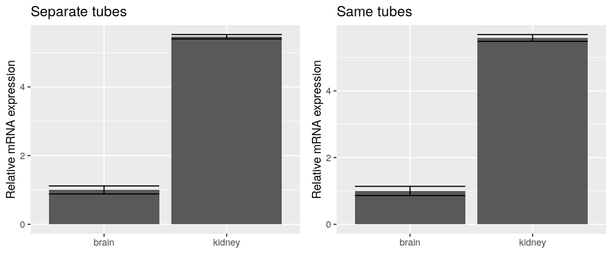

Figure 5: Relative expression of c-myc using the standard curve

```r
plot_grid(gg1, gg2)
```

## Test `pcr_test`

Testing for statistical significance between conditions is important to ensure validity and replicability of the analysis. Different statistical methods require different assumptions. So the choice of which test to use depends on many factors. Among these factors are the number of the conditions/groups, the sample and replicate sizes and the type of desired comparison.

`pcr_test` provides a unified interface to different testing methods, which is similar to that used before for analysis and quality assessment.

```r
# locate and read data
fl <- system.file('extdata', 'ct4.csv', package = 'pcr')
ct4 <- read.csv(fl)

# make group variable
group <- rep(c('control', 'treatment'), each = 12)
```

```r
# analyze the testing data
res <- pcr_analyze(ct4,
            group_var = group,
            reference_gene = 'ref',
            reference_group = 'control')
```

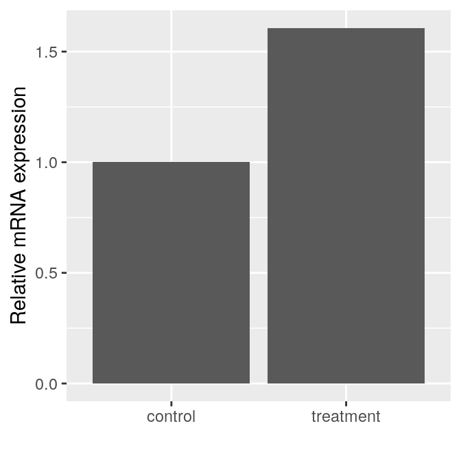

Figure 6: Relative expression of target gene using delta delta $C_T$

```r
ggplot(res, aes(x = group, y = relative_expression)) +
  geom_col() +
  labs(x = '', y = 'Relative mRNA expression')
```

We start by analyzing the dataset `ct4` using the default method of `pcr_analyze`, ‘delta_delta_ct’ and show a bar graph of the results (Fig. 6).

Finally we used the `pcr_test` to perform different tests. The resulting output tables can be compared to the results from the original paper that provided the dataset (Table 6).

```r
# test using t-test
tst1 <- pcr_test(ct4,
         group_var = group,
         reference_gene = 'ref',
         reference_group = 'control',
         test = 't.test')

knitr::kable(tst1, caption = 'Table 14: t-test summary')
```

Table 14: t-test summary

| gene | estimate | p_value | lower | upper |
| --- | --- | --- | --- | --- |
| target | -0.684825 | 3.43e-05 | -0.955952 | -0.413698 |

When the argument `test` is set to ‘t.test’ a simple two-group *t*-test is carried out and an `estimate` for the difference between groups for the change in the target relative to a control gene is provided. In addition, a `p_vale`, a `lower` and `upper` 95% confidence intervals are provided as well (Table 14).

```r
# test using wilcox.test
tst2 <- pcr_test(ct4,
         group_var = group,
         reference_gene = 'ref',
         reference_group = 'control',
         test = 'wilcox.test')

knitr::kable(tst2, caption = 'Table 15: Wilcoxon test summary')
```

Table 15: Wilcoxon test summary

| gene | estimate | p_value | lower | upper |
| --- | --- | --- | --- | --- |
| target | -0.6354 | 3e-06 | -0.8805 | -0.4227 |

When the argument `test` is set to ‘wilcox.test’, Wilcoxon test method is used instead and similar output is provided (Table 15).

The linear regression can be applied to more than two groups and more advanced comparisons.

```r
# testing using lm
tst3 <- pcr_test(ct4,
         group_var = group,
         reference_gene = 'ref',
         reference_group = 'control',
         test = 'lm')

knitr::kable(tst3, caption = 'Table 16: Linear regression summary')
```

Table 16: Linear regression summary

| gene | term | estimate | p_value | lower | upper |
| --- | --- | --- | --- | --- | --- |
| target | group_vartreatment | -0.684825 | 2.83e-05 | -0.9549519 | -0.4146981 |

The output of the `test`, ‘lm’ contains an extra column `term` to show the different comparison terms used to calculate the results (Table 16).

# Comparison with existing pacakges

Pabinger *et al.* surveyed the tools used to analyze qPCR data across different platforms (Pabinger et al. 2014). They included 9 R packages which provide very useful analysis and visualization methods. Some of these packages focuses one certain models and some are designed to handle high-throughput qPCR data. Most of these packages are hosted in CRAN and a few on the Bioconductor so they adhere to Bioconductor methods and data containers. In comparison, `pcr` provides a unified interface for different quality assessment, analysis and testing models. The input and the output are tidy `data.frame`, and the package source code follows the tidy-verse practices. This package is targets the small scale qPCR experimental data and there R user practitioner. The interface and documentation choices were made with such users in mind and require no deep knowledge in specific data structures or complex statistical models.

# Miscellaneous

In this section, we discuss briefly some common issues that arises when using real-time qPCR data and some simplified solutions using the `pcr` package. Mainly, we use linear models to quantify the effect of variables external to the reaction conditions on the resulting data and analysis. Either to identify such effects or to inform further experiments that are more likely to yield better results once the sources of the problems were removed. The examples are applied to the `ct4` dataset alone with some artificial variable.

## Testing advanced desgins and hypotheses

When considering testing, multiple variable in an experiment or their interactions the argument `model_matrix` should be used in `pcr_test`. The `model_matrix` should be constructed first to reflect the hypothesis at hand. For example, when having multiple dose of a treatment. A vector of numerical values is constructed first to indicate the `dose` that were used with each sample. Along with the main grouping variable `group`, they should be combined in a data.frame and the function `model.matrix` is used. The first argument to this function is the `formula` of the comparison.

```r
# testing advanced designs using a model matrix
# make a model matrix
group <- relevel(factor(group), ref = 'control')
dose <- rep(c(100, 80, 60, 40), each = 3, times = 2)
mm <- model.matrix(~group:dose, data = data.frame(group, dose))

# test using t-test
res <- pcr_test(ct4,
                reference_gene = 'ref',
                model_matrix = mm,
                test = 'lm')

knitr::kable(res, caption = "Table 17: Testing advanced hypotheses")
```

Table 17: Testing advanced hypotheses

| gene | term | estimate | p_value | lower | upper |
| --- | --- | --- | --- | --- | --- |
| target | model_matrixgroupcontrol:dose | 0.0048448 | 0.1752664 | -0.0023371 | 0.0120266 |
| target | model_matrixgrouptreatment:dose | -0.0035766 | 0.3121407 | -0.0107585 | 0.0036053 |

In this case, the `estimate` effect of the interaction term between `dose` and `group` is very small and the `p_value` is very large (Table 17).

## Varying RNA quality among samples

The quality of the RNA is very critical and should be measured and pass the minimum threshold. Including the scaled qualities , `quality`, can be added to an interaction term in a linear model, to rule out its effect on the analysis if suspected to have any.

```r
# using linear models to check the effect of RNA quality
# make a model matrix
group <- relevel(factor(group), ref = 'control')
set.seed(1234)
quality <- scale(rnorm(n = 24, mean = 1.9, sd = .1))
mm <- model.matrix(~group + group:quality, data = data.frame(group, quality))

# testing using lm
res <- pcr_test(ct4,
                reference_gene = 'ref',
                model_matrix = mm,
                test = 'lm')

knitr::kable(res, caption = "Table 18: Check the effect of varying RNA quality")
```

Table 18: Check the effect of varying RNA quality

| gene | term | estimate | p_value | lower | upper |
| --- | --- | --- | --- | --- | --- |
| target | model_matrixgrouptreatment | -0.6561369 | 0.0000301 | -0.9113989 | -0.4008748 |
| target | model_matrixgroupcontrol:quality | -0.2093469 | 0.0301799 | -0.3964965 | -0.0221973 |
| target | model_matrixgrouptreatment:quality | 0.0865875 | 0.3321284 | -0.0951329 | 0.2683078 |

The randomly generated `quality` seems to influence the results as indicated by the big `estimate` for the term ‘model_matrixgroupcontrol:quality’ and its `p_value` (Table 18).

## Combining data from multiple runs

The questions of whether it’s permissible to combine data from multiple runs depends on many factors. However, in practice it might be the only available option. In that case, one way to ensure the reliability of the data, is to use consider carefully which samples to run each time. Randomization or blocking can be used to avoid that batch effect or at least leave a chance to detect it if exists.

```r
# using linear model to check the effects of mixing separate runs
# make a model matrix
group <- relevel(factor(group), ref = 'control')
run <- factor(rep(c(1:3), 8))
mm <- model.matrix(~group + group:run, data = data.frame(group, run))

# test using lm
res <- pcr_test(ct4,
                reference_gene = 'ref',
                model_matrix = mm,
                test = 'lm')

knitr::kable(res, caption = "Table 19: Combining data from multiple qPCR runs")
```

Table 19: Combining data from multiple qPCR runs

| gene | term | estimate | p_value | lower | upper |
| --- | --- | --- | --- | --- | --- |
| target | model_matrixgrouptreatment | -0.681075 | 0.0126696 | -1.1979712 | -0.1641788 |
| target | model_matrixgroupcontrol:run2 | -0.057975 | 0.8163730 | -0.5748712 | 0.4589212 |
| target | model_matrixgrouptreatment:run2 | -0.103625 | 0.6786077 | -0.6205212 | 0.4132712 |
| target | model_matrixgroupcontrol:run3 | -0.129725 | 0.6044471 | -0.6466212 | 0.3871712 |
| target | model_matrixgrouptreatment:run3 | -0.095325 | 0.7029678 | -0.6122212 | 0.4215712 |

Here, we constructed a variable `run` to simulate a situation in which a dataset was generated in three separate runs. By including `run` in a `model_matrix`, its effect can be estimated. In this case, the `estimate` are very small and the `p_value` are very large, so it can be ignored (Table 19).

# Citation

```r
citation("pcr")
```

# Contribution

I’d be glad to receive any comments or ideas to help the package forward.

## Bug reporting

- To report a bug please use the [issue](https://github.com/MahShaaban/pcr/issues) page on github

## Code contributions

- Fork this repo to your github account
- Clone the repo to your machine and make changes
- Push to your account
- Submit a [pull](https://github.com/MahShaaban/pcr/pulls) request at this repo

## Contacts:

My email is: mahmoud.s.fahmy@students.kasralainy.edu.eg

# Notes

- It seems like there is a tiny mistake in the original table presented in (Livak and Schmittgen 2001) in calculating the average of $C_T$ values of the GAPDH in the brain samples and the subsequent calculations. The tables shown here from this study are the corrected ones.
- The original (Livak and Schmittgen 2001) serial dilution dataset provides only averages and standard deviations of $C_T$ values. We used these summaries to regenerate a dataset of raw $C_T$ values using the `rnorm(n = 3, mean = average, sd = sd)` to show how they could be used from the start in a typical analysis. So the subsequent calculations that involve this data set might be slightly different than the original tables in the paper.

# References

Livak, Kenneth J, and Thomas D Schmittgen. 2001. “Analysis of Relative Gene Expression Data Using Real-Time Quantitative PCR and the Double Delta CT Method.” *Methods* 25 (4). ELSEVIER. https://doi.org/10.1006/meth.2001.1262.

Pabinger, Stephan, Stefan Rodiger, Albert Kriegner, Klemens Vierlinger, and Andreas Weinhausel. 2014. “A Survey of Tools for the Analysis of Quantitative PCR (qPCR) Data.” *Biomolecular Detection and Quantification*. ELSEVIER. https://doi.org/10.1016/j.bdq.2014.08.002.

Yuan, Joshua S, Ann Reed, Feng Chen, and Neal Stewart. 2006. “Statistical Analysis of Real-Time PCR Data.” *BMC Bioinformatics* 7 (85). BioMed Central. https://doi.org/10.1186/1471-2105-7-85.